# Cost of Health Insurance

- Show All Code
- Hide All Code
- View Source

Author

Anna-Sophia Stocker

Published

June 13, 2023

```r
# Load libraries
library(here)
library(tidyverse)
library(rstatix)
library(unibeCols)
library(gtsummary)
```

## Introduction

The aim of this study is to compare the health insurance charges from women and men in the US.

## Data

The data used for this analysis is from the Medical Cost Personal Datasets, that are available open source on [Kaggle](https://www.kaggle.com/datasets/mirichoi0218/insurance?resource=download). We concentrate on the Charges-Data, the amount of health costs accumulated, by women and men in the US. Other available variables are ignored at this point.

```r
# Read and transform data
insurance <- read_csv(here("data/raw/insurance_with_date.csv"))
insurance$sex <- as.factor(insurance$sex)
str(insurance)
```

## Results

### Descriptive Statistics

Table 1 shows the basic descriptive values of the health insurance charges separate by men and women.

```r
insurance |>
  tbl_summary(
    by = sex,
    type = all_continuous() ~ "continuous2",
    statistic = all_continuous() ~ c("{mean} ({sd})", "{median}", "{p25} - {p75}", "{min}", "{max}"),
    include = c("sex", "charges")
  )
```

Table 1: Overview of the data on health charges for women and men

| **Characteristic** | **female**, N = 662 | **male**, N = 676 |
| --- | --- | --- |
| charges |  |  |
| Mean (SD) | 14,232 (11,175) | 15,646 (12,975) |
| Median | 11,107 | 11,166 |
| IQR | 6,417 - 16,623 | 6,264 - 20,301 |
| Minimum | 1,778 | 1,382 |
| Maximum | 66,740 | 64,762 |

A Boxplot (Figure 1) shows the distribution of charges by women and men. On first glance, the data for women and men look quite similar, but with the distribution skewed to the lower end.

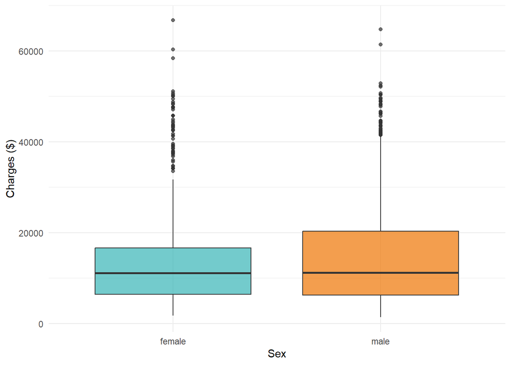

(a) Whiskers at 1.5 IQR

Figure 1: Boxplot of the distribution of health charges by sex

```r
ggplot(data = insurance, aes (x = sex, y = charges, fill = sex))+
  geom_boxplot(alpha = 0.7) +
    scale_fill_manual(name = "sex",
                  breaks = c("male", "female"),
                  values = c(unibeApricotS()[1], unibeMintS()[1]),
                  labels = c("male", "female")) +
    scale_colour_manual(name = "sex",
                  breaks = c("male", "female"),
                  values = c(unibeApricotS()[1], unibeMintS()[1]),
                  labels = c("male", "female"))+
  ylab(label = "Charges ($)") +
  xlab("Sex") +
  theme_minimal() +
    theme(legend.position = "none")
```

#### Analysis of Normality

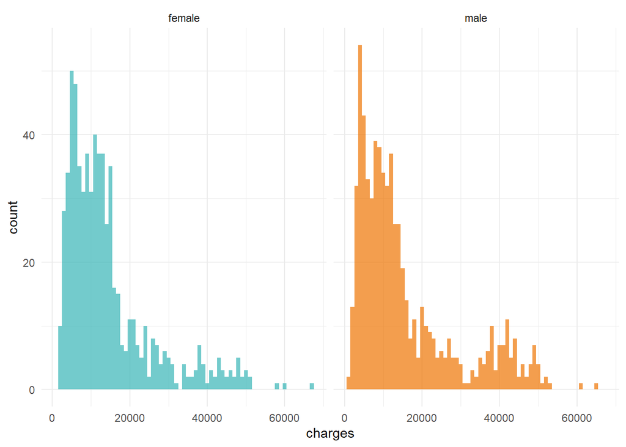

Figure 2: Histogram of the distribution of health charges by sex

```r
# Histogram data by sex
ggplot(data = insurance, aes(x = charges, fill = sex)) +
  geom_histogram(alpha = 0.7, binwidth = 1000)+
  facet_wrap("sex")+
  scale_fill_manual(name = "sex",
                    breaks = c("male", "female"),
                    values = c(unibeApricotS()[1], unibeMintS()[1]),
                    labels = c("male", "female")) +
  scale_colour_manual(name = "sex",
                      breaks = c("male", "female"),
                      values = c(unibeApricotS()[1], unibeMintS()[1]),
                      labels = c("male", "female"))+
  theme_minimal() +
  theme(legend.position = "none")
```

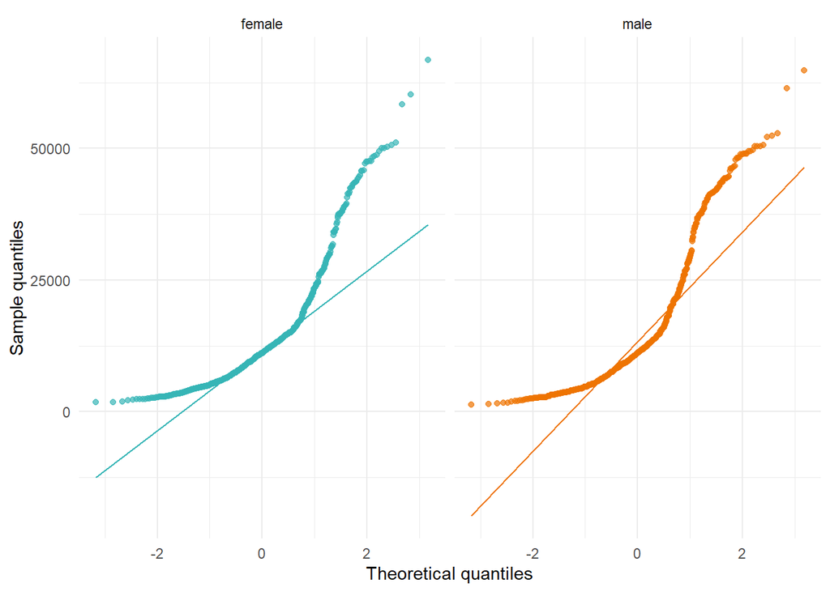

Figure 3: QQ-Plot of health-charges data

```r
# QQ-Plot data by sex

insurance |>
  ggplot(aes(sample = charges, colour = sex, fill = sex)) +
  geom_qq_line(distribution = stats::qnorm)+
  geom_qq(alpha = 0.7)+
  facet_wrap("sex")+
  scale_fill_manual(name = "sex",
                  breaks = c("male", "female"),
                  values = c(unibeApricotS()[1], unibeMintS()[1]),
                  labels = c("male", "female")) +
  scale_colour_manual(name = "sex",
                      breaks = c("male", "female"),
                      values = c(unibeApricotS()[1], unibeMintS()[1]),
                      labels = c("male", "female"))+
  ylab(label = "Sample quantiles") +
  xlab("Theoretical quantiles") +
  theme_minimal() +
  theme(legend.position = "none")
```

```r
# Test for Normality data by sex
insurance |>
  group_by(sex) |>
  shapiro_test(charges)
```

Table 2: Shapiro-test for Normality

| sex | variable | statistic | p |
| --- | --- | --- | --- |
| female | charges | 0.8167897 | 8.957940e-27 |
| male | charges | 0.8296552 | 3.279539e-26 |

#### Transformation of data

A log-transformation of the Charges-Data was performed and Histogram (Figure 4) and QQ-Plot (Figure 5) repeated with the transformed Data. The distribution now looks closer to a normal distribution, although a Shapiro-Test for Normality (Table 3) still indicates non-normality.

```r
# Transform data
insurance$logcharges <- log(insurance$charges)
```

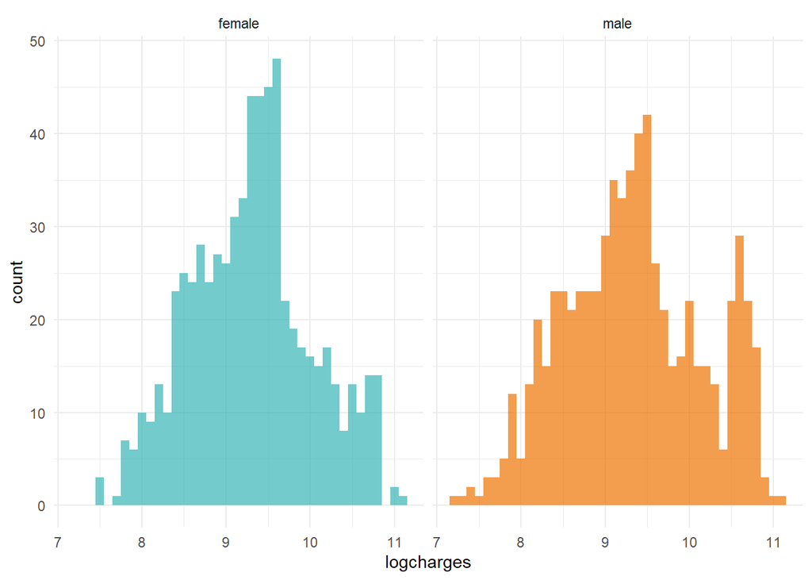

Figure 4: Histogram of the distribution of the log-transformed health charges by sex

```r
# Histogram of transformed data
ggplot(data = insurance, aes(x = logcharges, fill = sex)) +
  geom_histogram(alpha = 0.7, binwidth = 0.1)+
  facet_wrap("sex")+
  scale_fill_manual(name = "sex",
                    breaks = c("male", "female"),
                    values = c(unibeApricotS()[1], unibeMintS()[1]),
                    labels = c("male", "female")) +
  scale_colour_manual(name = "sex",
                      breaks = c("male", "female"),
                      values = c(unibeApricotS()[1], unibeMintS()[1]),
                      labels = c("male", "female"))+
  theme_minimal() +
  theme(legend.position = "none")
```

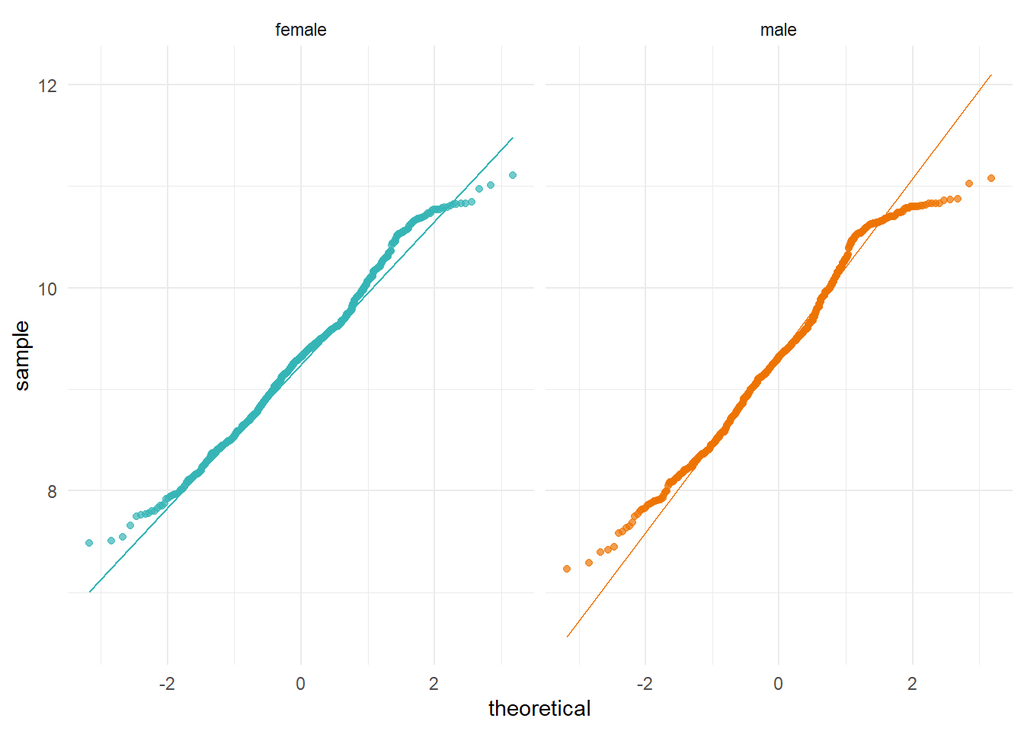

Figure 5: QQ-Plot of log-transformed health-charges data

```r
# QQ-Plot of transformed data
insurance |>
  ggplot(aes(sample = logcharges, ill = sex, colour = sex)) +
  geom_qq_line(distribution = stats::qnorm)+
  geom_qq(alpha = 0.7)+
  facet_wrap("sex")+
  scale_fill_manual(name = "sex",
                  breaks = c("male", "female"),
                  values = c(unibeApricotS()[1], unibeMintS()[1]),
                  labels = c("male", "female")) +
  scale_colour_manual(name = "sex",
                      breaks = c("male", "female"),
                      values = c(unibeApricotS()[1], unibeMintS()[1]),
                      labels = c("male", "female"))+
  theme_minimal() +
  theme(legend.position = "none")
```

```r
# Test for normality on transformed data
insurance |>
  group_by(sex) |>
  shapiro_test(logcharges)
```

Table 3: test for normality on transformed data

| sex | variable | statistic | p |
| --- | --- | --- | --- |
| female | logcharges | 0.9914076 | 6.857878e-04 |
| male | logcharges | 0.9822474 | 2.618879e-07 |

#### Inferential statistics

A t-Test (Table 4) on the transformed data and a Wilcoxon rank sum test (Table 5) on the non-transformed data were executed. Both tests are not statistically significant.

```r
# T-test on transformed data
insurance |>
    t_test(logcharges ~ sex)
```

Table 4: t-test on transformed health charges data

|  | .y. | group1 | group2 | n1 | n2 | statistic | df | p |
| --- | --- | --- | --- | --- | --- | --- | --- | --- |
| 1 | logcharges | female | male | 662 | 676 | -0.8299748 | 1323.437 | 0.407 |

```r
# Test on original data
insurance |>
  wilcox_test(charges ~ sex)
```

Table 5: wilcoxon rank sum test on original health charges data

|  | .y. | group1 | group2 | n1 | n2 | statistic | p |
| --- | --- | --- | --- | --- | --- | --- | --- |
| 1 | charges | female | male | 662 | 676 | 219691 | 0.565 |

## Conclusions

There is no indication of a statistical connection of sex and amount of health charges in the US.